# Python in SSMS

2018-11-07

## Me

- Owner Look at your Data
- Masters student Data Science, University of Dundee
- I bloomin' love this stuff

## You

- Python
- R
- SQL
- All three?
- Primary coding language

## Goals

- Explanation
- Empowerment
- Justification
- …NB…
- That leaves quite a lot this *isn't* about

## Method

- Explanation of SQL (all apologies)
- Explanation of Python
- "Hello world"
- Whoa there, Neddy!
- Environments
- Let's do this

## SQL

```sql
SELECT @@VERSION
```

1 records

| Microsoft SQL Server vNext (CTP2.0) - 15.0.1000.34 (X64) |
| --- |

```
Sep 18 2018 02:32:04
Copyright (C) 2018 Microsoft Corporation
Developer Edition (64-bit) on Windows 10 Pro 10.0 <X64> (Build 17134: ) (Hypervisor) |
```

## Environment SQL

- Uninstalled everything
- I installed SQL vNext (Developer Edition) from here https://www.microsoft.com/evalcenter/evaluate-sql-server-2019-ctp
- I chose Select All at feature selection
- (Warning: Bit of a nightmare on Linux)
- SQL Configuration: Enable TCP/IP
- Restart
- EXEC sp_configure 'external scripts enabled', 1;
- Start Launchpad (Or see this:

  SQL Server was unable to communicate with the LaunchPad service for request id

  )

## SQL to Python: Behind the scenes part one

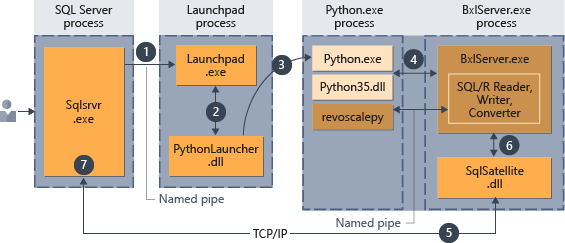

image from https://docs.microsoft.com/en-us/sql/advanced-analytics/concepts/extension-python?view=sql-server-2017

## SQL to Python: Behind the scenes part two

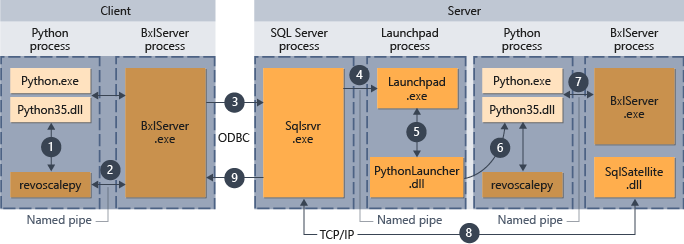

image from https://docs.microsoft.com/en-us/sql/advanced-analytics/concepts/extension-python?view=sql-server-2017

## Now let's do some python

- Shall we go to SSMS?<sup>1</sup>

## Whoa there, Neddy!

- Just because we present as normal does not mean we are
- Let's just back up

## Python

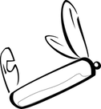

image from: http://res.publicdomainfiles.com/pdf_view/84/13939534812707.png

- Scripts (and/or RBAR)
- General purpose
- Being something other people are good at
- Adopted by Data Science

## Python environment

- pip
- https://docs.microsoft.com/en-us/sql/advanced-analytics/python/install-additional-python-packages-on-sql-server?view=sql-server-2017
- what this means
- cd "C:\Program Files\Microsoft SQL Server\MSSQL15.LAYDSQL2019\PYTHON_SERVICES\Scripts"
- **this folder is your friend**
- pip install boto3 (say)
- what else have we got?
- spyder anyone?

## Can we code yet

- Not quite
- Quick refresher<sup>2</sup>

## Recap

- Enabled scripts … not yet done
- Launched, erm, LaunchPad … not yet done
- Ran some SSMS-based Python … not yet done(!)
- Met pip … not yet done
- Embraced pip … let's code

## Web scraping

- Ask sysadmin first
- We will use https://www.theguardian.com/football/premierleague/table (non-commercially!)<sup>3</sup>
- You should check a website’s Terms and Conditions before you scrape it. Be careful to read the statements about legal use of data. Usually, the data you scrape should not be used for commercial purposes.
- Do not request data from the website too aggressively with your program (also known as spamming), as this may break the website. Make sure your program behaves in a reasonable manner (i.e. acts like a human). One request for one webpage per second is good practice.
- The layout of a website may change from time to time, so make sure to revisit the site and rewrite your code as needed

(taken from: https://medium.freecodecamp.org/how-to-scrape-websites-with-python-and-beautifulsoup-5946935d93fe)

## Hacks

- always use " not ' in Python code
- always use NVARCHAR (and declare @p = N'something')
- *think* sysadmin

## Python in SSMS

- Do we need it?!
- Familiarity is a big reason
- Lack of good ORM tools another and/or faith in SSMS
- Need to trial stohastic processes

## Stretch goal: Kmeans

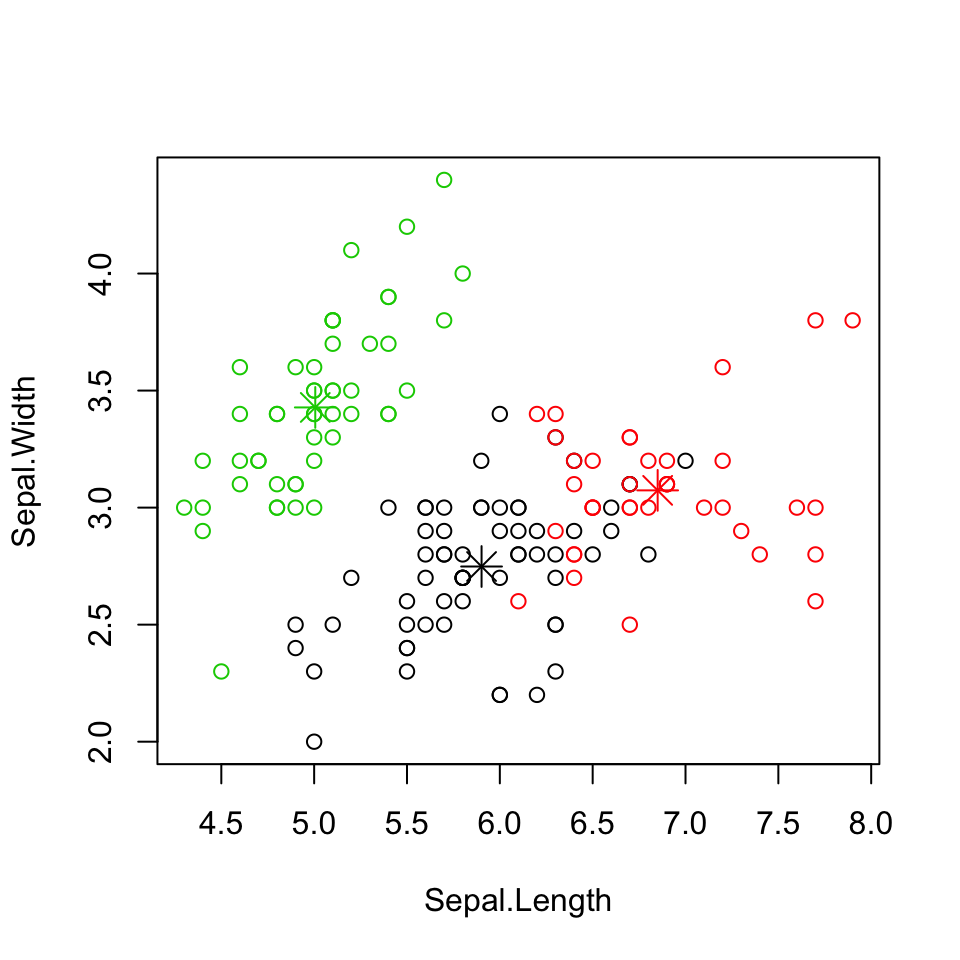

From (amongst other places): http://rstudio-pubs-static.s3.amazonaws.com/3446_e5bd18f593e54b3fb4ca9d283158f560.html

## Stretch goal: Kmeans

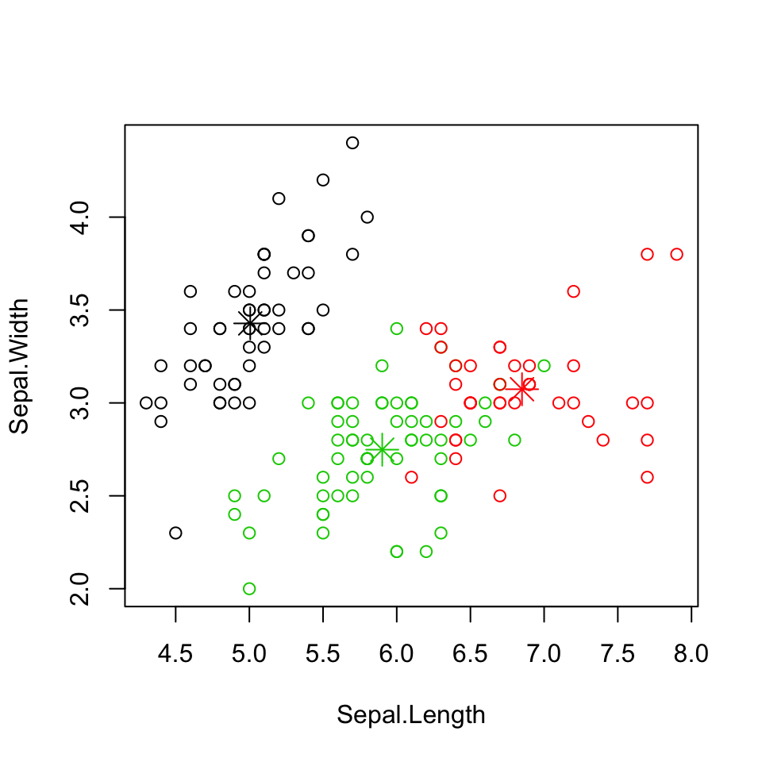

## Stretch goal: Kmeans

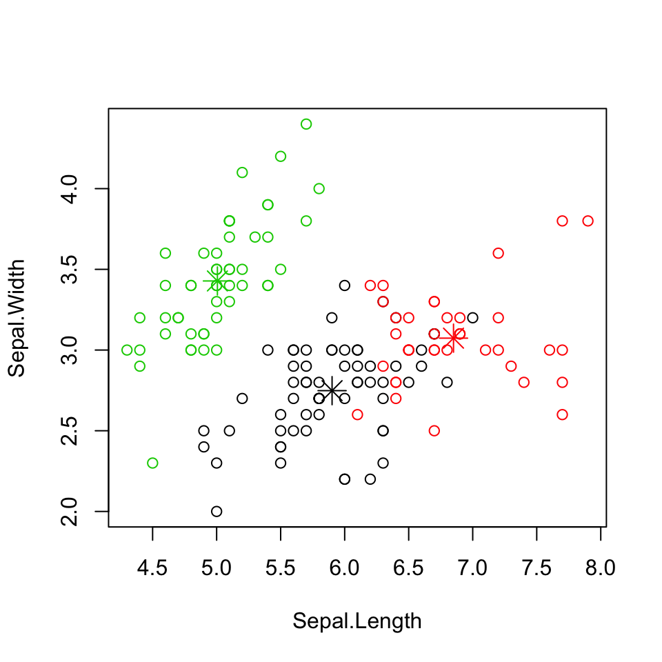

## Stretch goal: Kmeans

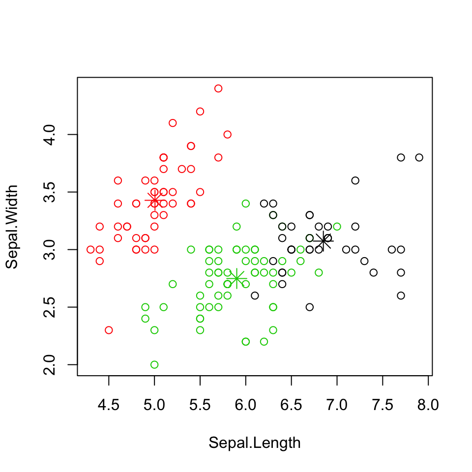

## Stretch goal: Kmeans

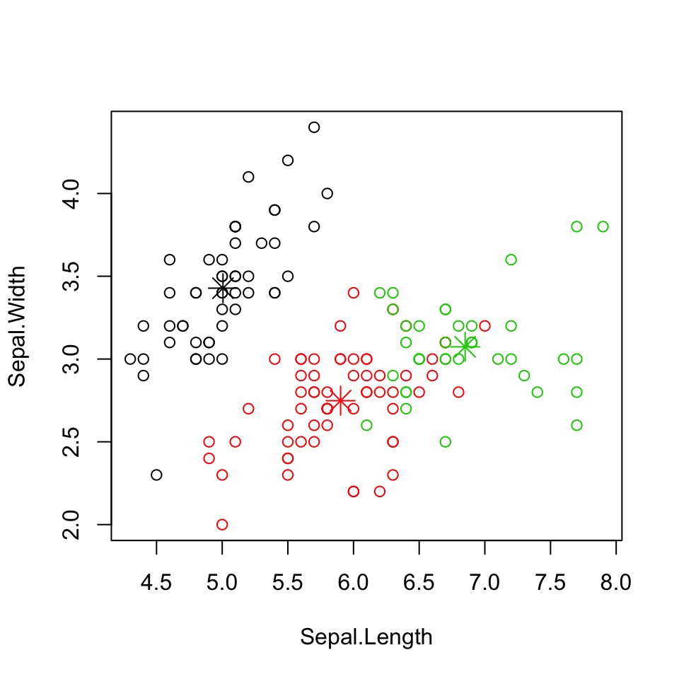

## Stretch goal: Kmeans

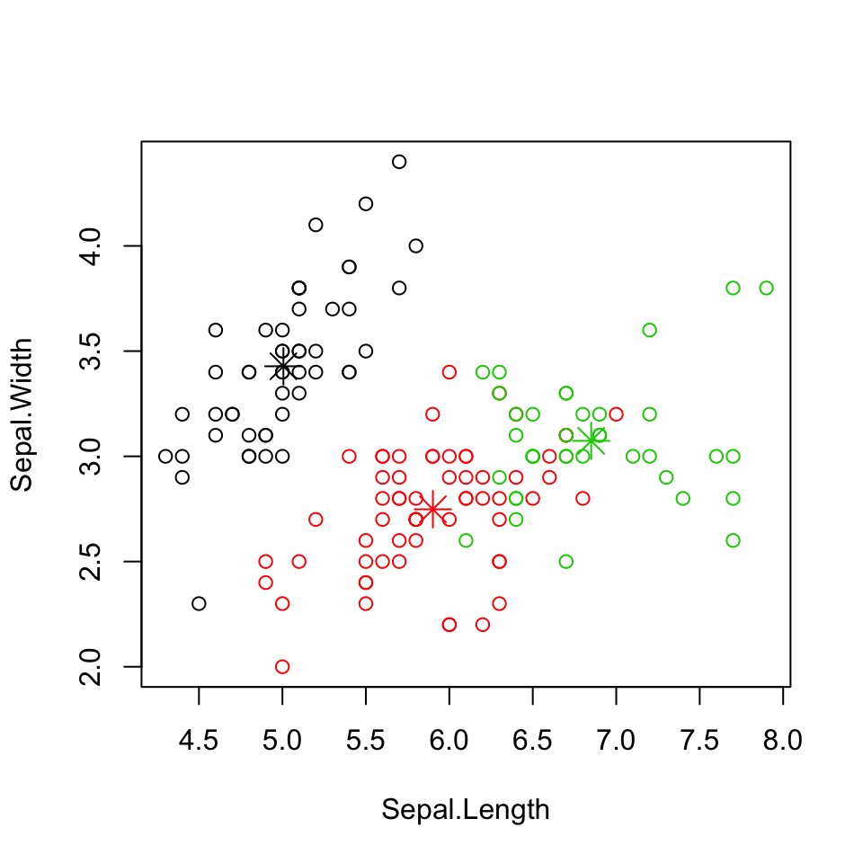

## Stretch goal: Kmeans

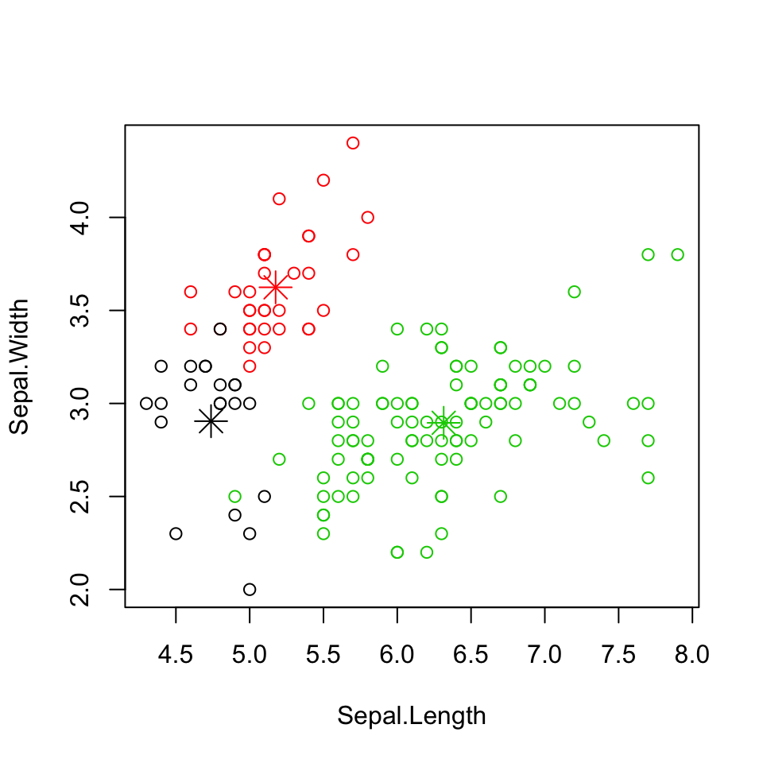

## Stretch goal: Kmeans

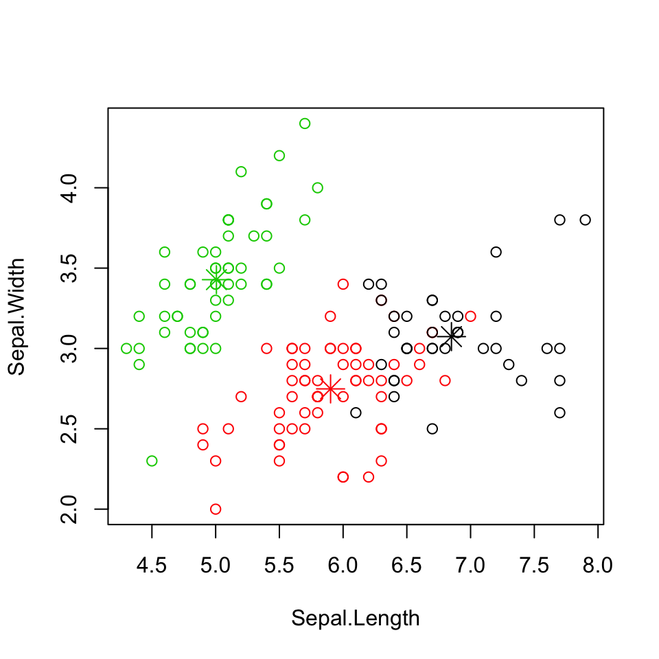

## Stretch goal: Kmeans

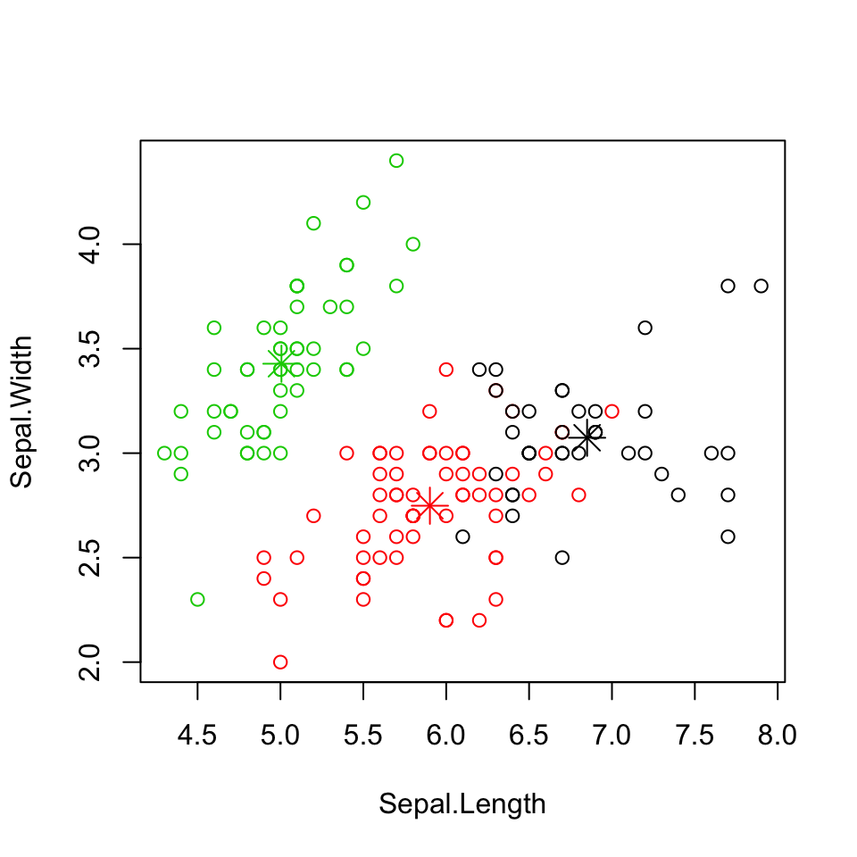

## Why it makes SQL important

- Trials!
- https://app.powerbi.com/view?r=eyJrIjoiZWNiNDcwYjYtOWFkYS00MjgyLTkwZGUtZGQ0NmI1ODkxMzJmIiwidCI6IjdhZDRlMDg1LWE3ZWMtNDZlOC1hODIwLWI5MjM1NDRmMGVhOCJ9

## Community profile

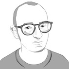

image by @iBenWild

- GitHub<sup>4</sup>: https://github.com/databackwriter
- Blog: https://databackwriter.com
- Twitter: https://twitter.com/thedatabloke
- LinkedIn: https://www.linkedin.com/in/lookatmydata/
- StackOverflow: https://stackexchange.com/users/12936623/pete-moore
- available for work: pete@lookatyourdata.com